# Week 5 - Homework

Author

David Gonzalez Chavez

# Data

The data for this homework assignment comes from the 2022 GSS.

```r
gss2022 <- gss_get_yr(year = 2022) |> # get 2022 GSS data
  haven::zap_labels()                 # remove labels
```

# Variable #1:

The first variable I am using from the 2022 GSS is the number of hours per day respondents have to relax (hrsrelax). It is a continuous variable.

```r
hrs_data <- gss2022 |>
  select(hrsrelax) |> # select the hrsrelax variable
  drop_na() # drop any rows with N/A values
```

## Histogram

For reference, below is a histogram showing the distribution of “hrsrelax”

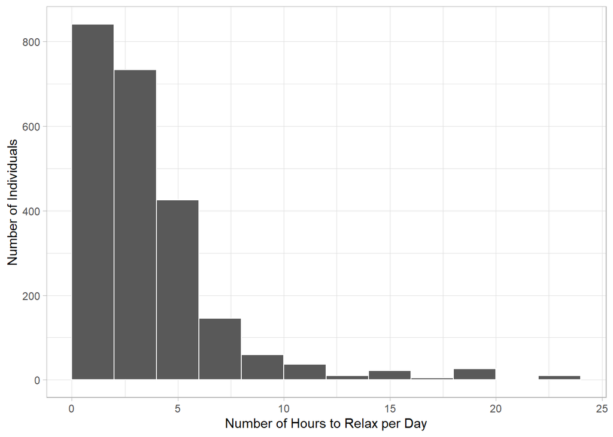

```r
ggplot(hrs_data,
       aes(x = hrsrelax)) +
  geom_histogram(color = "white",
                 binwidth = 2, # set bin width to 2, ensures a reasonable number of bins
                 boundary = 0) +
  xlab("Number of Hours to Relax per Day") +
  ylab("Number of Individuals")
```

## Mean, SD, and Confidence Intervals

```r
ci_89_hrs = qt(p=0.5+(.89/2), df = nrow(hrs_data) - 1) # get the number of SDs above/below to get confidence interval. p is the desired percentile (50% - half of the desired percentile, which I can + or - to the mean to get my desired CI)

ci_95_hrs = qt(p=0.5+(.95/2), df = nrow(hrs_data) - 1)

ci_99_hrs = qt(p=0.5+(.99/2), df = nrow(hrs_data) - 1)
```

The mean for this variable is 4. The standard deviation for this variable is 4. An 89% confidence interval is between -1.62165 and 9.8322671. A 95% confidence interval is between -2.9189944 and 11.1296116. A 99% confidence interval is between -5.128976 and 13.3395932.

It is not accurate to say that we are 89/95/99% certain that the correct value is in those ranges. Instead, (copied verbatim from slides), “if we did the same study infinite times, [89/95/99]% of the computed intervals would contain the true value.”

# Variable #2:

The first variable I am using from the 2022 GSS is respondent’s confidence in the existence of god (god), which I make binary by setting those who believe with no doubts to 1 and all others to 0 in my constructed variable “confident_believer.”

```r
god_data <- gss2022 |>
  select(god) |> # select the god variable
  drop_na() |> # drop any rows with N/A values
  mutate(confident_believer = if_else(god == 6, 1, 0)) |> # anyone who responded they believe with no doubts is a confident believer, all others are not
  select(confident_believer)
```

## Bar Chart

For reference, below is a histogram showing the distribution of “confident_believer.” Please note it’s almost 50/50.

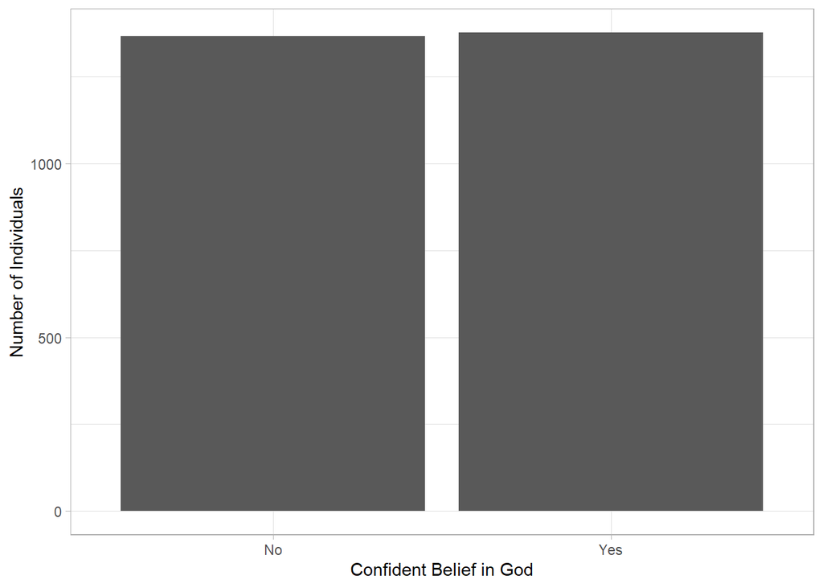

```r
bar_chart_data = god_data |>
  mutate(Is_Confident_Believer = if_else(confident_believer == 1, "Yes", "No"))

ggplot(bar_chart_data,
       aes(x = Is_Confident_Believer)) +
  geom_bar() +
  xlab("Confident Belief in God") +
  ylab("Number of Individuals")
```

## Mean, SD, and Confidence Intervals

```r
mean_god = mean(god_data$confident_believer) # mean for a bernoulli distribution is the probability of 1, which we can just calculate with the mean formula

variance_god = mean_god * (1 - mean_god) # variance is p(1-p)

sd_god = variance_god^(1/2) # sd is sqrt of variance

ci_89_god = qt(p=0.5+(.89/2), df = nrow(god_data) - 1) # get the number of SDs above/below to get confidence interval. p is the desired percentile (50% - half of the desired percentile, which I can + or - to the mean to get my desired CI)

ci_95_god = qt(p=0.5+(.95/2), df = nrow(god_data) - 1)

ci_99_god = qt(p=0.5+(.99/2), df = nrow(god_data) - 1)
```

The mean for this variable is 0.5 and the standard deviation for this variable is 0.5. An 89% confidence interval is between -0.2975269 and 1.3011739. A 95% confidence interval is between -0.4785849 and 1.4822319. A 99% confidence interval is between -0.78698 and 1.790627.

It is not accurate to say that we are 89/95/99% certain that the correct value is in those ranges. Instead, (copied verbatim from slides), “if we did the same study infinite times, [89/95/99]% of the computed intervals would contain the true value.” Either way, this is not very helpful since the range is so big and contains impossible values (i.e., below 0 and above 1).